# Add Health

The National Longitudinal Study of Adolescent to Adult Health (Add Health) is a longitudinal study of a nationally representative sample of adolescents in grades 7-12 in the United States during the 1994-95 school year. The Add Health cohort has been followed into young adulthood with four in-home interviews, the most recent in 2008, when the sample was aged 24-32. Add Health is re-interviewing cohort members in a Wave V follow-up from 2016-2018 to collect social, environmental, behavioral, and biological data with which to track the emergence of chronic disease as the cohort moves through their fourth decade of life.

More info at: http://www.cpc.unc.edu/projects/addhealth

# Import

This is a CSV file, so we could read it in using `read.csv` but I prefer the functionality of `read_csv` found in the `readr` package.

```r
library(readr)
rawdata <- read_csv(file="AddHealth_Wave_IV.csv")
```

## Trim down variables

Goof ups are bound to happen. Let’s rename our `rawdata` as `mydata`, and do all our data cleaning on `mydata`. That way if/when we goof up, we just need to run the code chunk below and it will reset `mydata` back to pre-recodes (and not have to read the entire CSV data set from the hard drive all over again.)

```r
mydata <- rawdata
```

We could use dplyr to `%>% select()` only variables we want to keep on the data set in this above code chunk, but we can also “clean up” the data set at the end before saving the clean file to disk.

# Recode variables

### Gender

BIO_SEX is coded as 1=male, 2=female, 6=missing. I want to recode this into an indicator of being female.

```r
mydata$female <- mydata$BIO_SEX-1
mydata$female[mydata$BIO_SEX==6] <- NA
table(mydata$BIO_SEX, mydata$female ,useNA="always")
```

```
##
##           0    1 <NA>
##   1    3147    0    0
##   2       0 3356    0
##   6       0    0    1
##   <NA>    0    0    0
```

For plotting purposes, I would also like to have a categorical version of gender.

```r
mydata$female_c <- factor(mydata$female, labels=c("Male", "Female"))
table(mydata$female, mydata$female_c ,useNA="always")
```

```
##
##        Male Female <NA>
##   0    3147      0    0
##   1       0   3356    0
##   <NA>    0      0    1
```

### General Health

```r
table(mydata$H4GH1)
```

```
##
##    1    2    3    4    5
##  979 1963 1683  434   55
```

```r
mydata$genhealth <- factor(mydata$H4GH1,
                              labels = c("Excellent", "Very good", "Good", "Fair", "Poor"))
```

### Relationships

With how many people have you had a romantic or sexual relationship that lasted less than 6 months since 2001?

```r
table(mydata$H4TR6)
```

```
##
##    0    1    2    3    4    5    6    7    8    9   10   11   12   13   14
## 3049  515  424  261  176  137   74   41   46   18   95    6   23    9    6
##   15   16   17   18   20   21   22   23   24   25   26   28   30   37   38
##   28    1    2    3   25    2    1    1    1   11    3    4   10    1    1
##   40   45   50   60   65   75   90   95  996  998
##    3    1    8    4    1    1    1    7   40   74
```

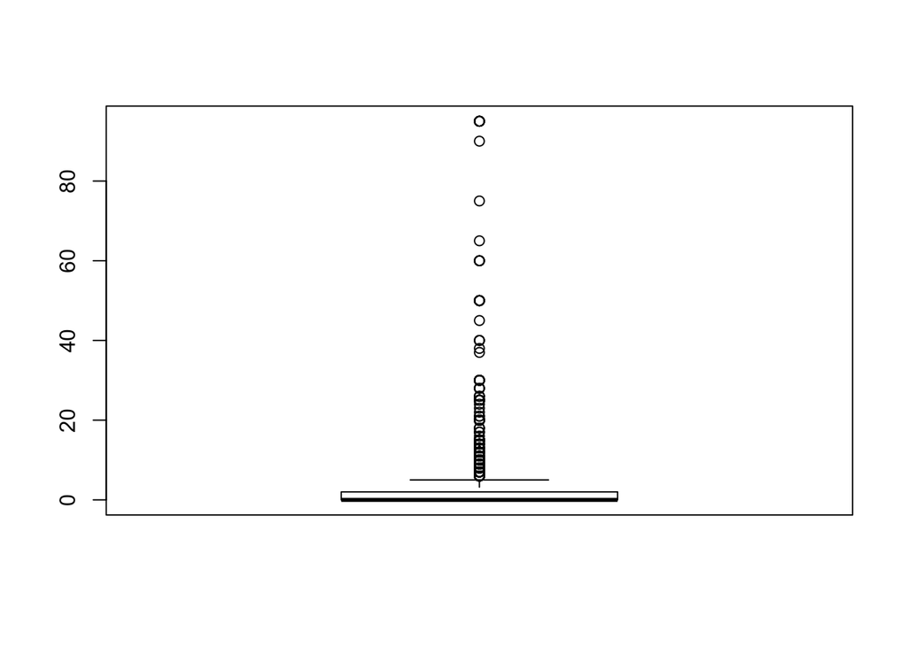

```r
mydata$H4TR6[mydata$H4TR6 >990] <- NA
boxplot(mydata$H4TR6)
```

Median number of opposite-sex partners in lifetime among sexually experienced men and women aged 25-44 years of age 2002, 2006-2010 and 2011-2015: 6.7 for men, 3.8 for women. Key Statistics from the National Survey of Family Growth - N Listing https://www.cdc.gov/nchs/nsfg/key_statistics/n.htm

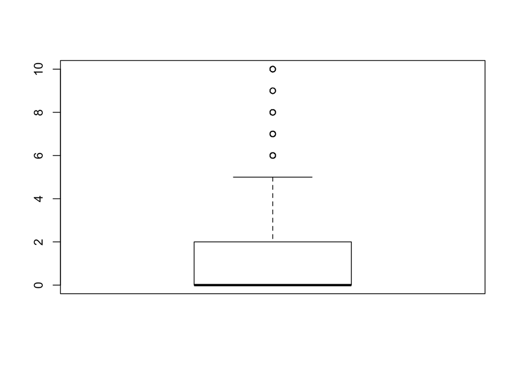

```r
mydata$casual_part <- ifelse(mydata$H4TR6 > 10, 10, mydata$H4TR6)
boxplot(mydata$casual_part)
```

## Number of jobs

```r
table(mydata$H4LM3)
```

```
##
##    0    1    2    3    4    5    6    7    8    9   10   11   12   13   15
##   54  889 1138 1090  685  481  255  138   75   40   93    8   18    2   14
##   16   18   20   22   23   25   30   50   96   97   98
##    2    2   16    2    1    2    3    3    3   96    4
```

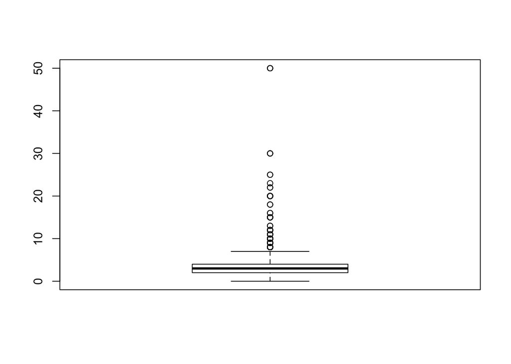

```r
mydata$H4LM3[mydata$H4LM3 >90] <- NA
boxplot(mydata$H4LM3)
```

```r
mydata$njobs <-mydata$H4LM3
```

### BMI

```r
summary(mydata$H4BMI)
```

```
##    Min. 1st Qu.  Median    Mean 3rd Qu.    Max.    NA's
##   14.40   23.70   27.80   42.49   33.40  999.00    1390
```

There are out of range variables here. Check codebook and remove using an `ifelse` statement that says *Make a new variable `BMI`. If `H4BMI` is less than 100 set `BMI` equal to `H4BMI`. Otherwise (if `H4BMI` is $geq$ 100) set `BMI` to missing*.

```r
mydata$BMI <- ifelse(mydata$H4BMI < 100, mydata$H4BMI, NA)
```

### Blood Pressure Class

```r
table(mydata$H4BPCLS)
```

```
##
##    1    2    3    4    6    7    9
## 1718 2269  791  205   48    4   36
```

Set missing and change labels

```r
mydata$H4BPCLS[mydata$H4BPCLS %in% c(6, 7, 9)] <- NA
mydata$bp_class <- factor(mydata$H4BPCLS, labels = c('Normal', 'Pre-HTN', 'HTN-I', 'HTN-II'))
table(mydata$H4BPCLS, mydata$bp_class, useNA="always")
```

```
##
##        Normal Pre-HTN HTN-I HTN-II <NA>
##   1      1718       0     0      0    0
##   2         0    2269     0      0    0
##   3         0       0   791      0    0
##   4         0       0     0    205    0
##   <NA>      0       0     0      0 1521
```

### Sleep

#### Wake up on workdays

Time they wake up on workdays consists of three variables: hours (`H4SP1H`), minutes(`H4SP1M`) and if the time listed is in AM or PM (`H4SP1T`). I want to convert this to a continuous 24 hour time variable.

- First set values to missing

```r
mydata$H4SP1T[mydata$H4SP1T %in% c(6, 8)] <- NA
mydata$H4SP1M[mydata$H4SP1M %in% c(96, 98)] <- NA
mydata$H4SP1H[mydata$H4SP1H %in% c(96, 98)] <- NA
```

Confirm

```r
table(mydata$H4SP1H, useNA="always")
```

```
##
##    1    2    3    4    5    6    7    8    9   10   11   12 <NA>
##   40   48   95  309 1007 1582 1078  406  261  139   72   64 1403
```

```r
summary(mydata$H4SP1M, useNA="always")
```

```
##    Min. 1st Qu.  Median    Mean 3rd Qu.    Max.    NA's
##    0.00    0.00    0.00   13.77   30.00   59.00    1404
```

```r
table(mydata$H4SP1T, useNA="always")
```

```
##
##    1    2 <NA>
## 4843  258 1403
```

- Recode am/pm to numbers of hours to add (0 for AM, 12 for PM).

```r
mydata$ampm <- car::recode(mydata$H4SP1T, "1=0; 2=12")
```

But we don’t want to add 12 hours to 12pm, so we need to change the rows when hours = 12 and time = pm to not add any time.

```r
mydata$ampm[mydata$H4SP1H == 12 & mydata$H4SP1T == 2] <- 0
```

- Now create 24 hour time by adding hours + am/pm + minutes

```r
mydata$wakeup <- mydata$H4SP1H + mydata$ampm + mydata$H4SP1M/60
summary(mydata$wakeup)
```

```
##    Min. 1st Qu.  Median    Mean 3rd Qu.    Max.    NA's
##   1.000   5.750   6.500   7.023   7.500  23.500    1404
```

Wake up times range from 1am to 11:30 pm. No out of range times seen.

Check to make sure the times added up correctly. Print out the top 5 rows (using `slice`) for only the time columns (`select`), and dropping the rows with missing values (`na.omit`)

```r
library(dplyr)
mydata %>% select(H4SP1H, H4SP1M, ampm, wakeup) %>% na.omit %>% slice(1:5)
```

```
## # A tibble: 5 x 4
##   H4SP1H H4SP1M  ampm wakeup
##    <int>  <int> <dbl>  <dbl>
## 1      6      0     0    6.0
## 2      9      0     0    9.0
## 3      6     30     0    6.5
## 4      9     30     0    9.5
## 5      5      0     0    5.0
```

Row 1 check: 6 hours, 0 minutes, am, –> 0600 (6). Row 3 check: 6 hours, 30 minutes, am –> 0630 (6.5). Time was calculated correctly.

#### Bedtime up on workdays

```r
mydata$H4SP2T[mydata$H4SP2T %in% c(6, 8)] <- NA
mydata$H4SP2M[mydata$H4SP2M %in% c(96, 98)] <- NA
mydata$H4SP2H[mydata$H4SP2H %in% c(96, 98)] <- NA

mydata$ampm2 <- car::recode(mydata$H4SP2T, "1=0; 2=12")
mydata$ampm2[mydata$H4SP2H == 12 & mydata$H4SP2T == 2] <- 0
mydata$bedtime <- mydata$H4SP2H + mydata$ampm2 + mydata$H4SP2M/60
summary(mydata$bedtime)
```

```
##    Min. 1st Qu.  Median    Mean 3rd Qu.    Max.    NA's
##    1.00   12.00   22.00   17.23   23.00   23.98    1402
```

We lost people who went to bed or woke up between 12 and 1am - whups.

Indicator for people who likely work the night shift - go to bed between 5am and 3pm

```r
odd.sleep.records <- which(mydata$bedtime > 5 & mydata$bedtime < 15)

# Not run -- run this line if you want to limit your analysis sample to only those with "normal" sleep schedule
#mydata <- mydata[-odd.sleep.records,]
```

### Sleep Duration

Only useful after eliminating those with odd sleep patterns (above)

```r
# people who go to bed early are expected to wake up before midnight.
mydata$sleep_duration <- mydata$wakeup - mydata$bedtime

# these people go to bed after 3pm, but before midnight. Get list of records where this occurs
normal.sleep.records <- which(mydata$bedtime < 24 & mydata$bedtime > 15)

# for these people who sleep over midnight, calculate their sleep duration.
mydata$sleep_duration[normal.sleep.records] <- (24-mydata$bedtime[normal.sleep.records]) +
                                                      mydata$wakeup[normal.sleep.records]
summary(mydata$sleep_duration)
```

```
##    Min. 1st Qu.  Median    Mean 3rd Qu.    Max.    NA's
##  -9.500   6.000   7.500   5.467   8.000  31.000    1404
```

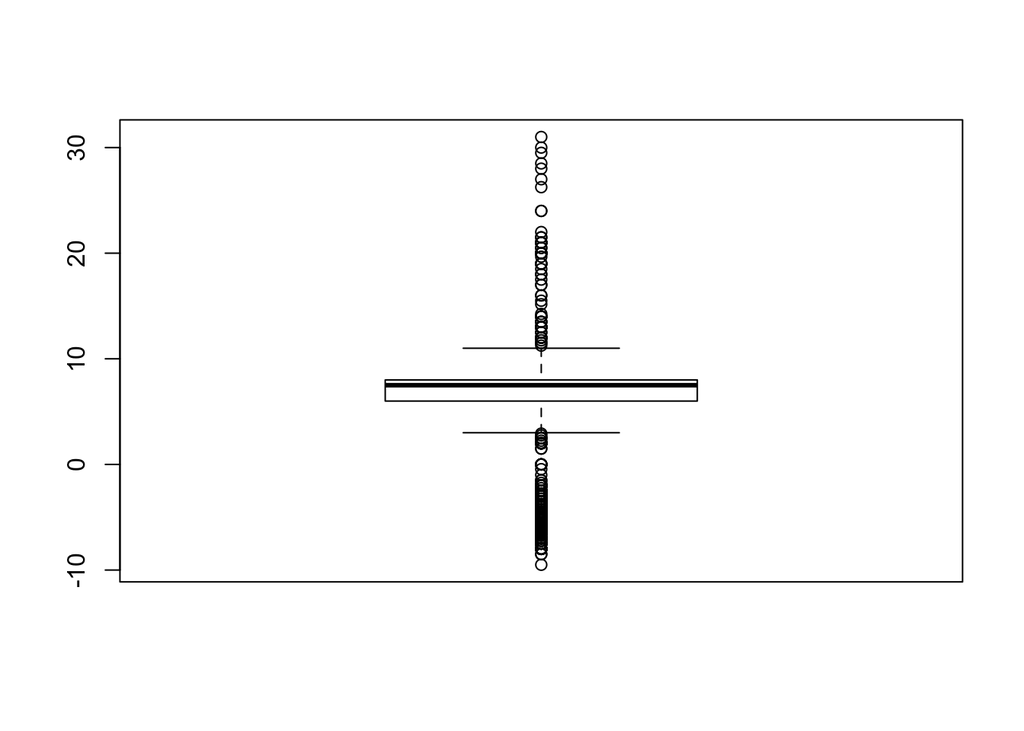

```r
boxplot(mydata$sleep_duration)
```

```r
# not run
# also kick out ppl with calculated sleep time over 12 h
#mydata <- filter(mydata, sleep_duration > 12)
```

## Smoking (H4TO1)

```r
table(mydata$H4TO1)
```

```
##
##    0    1    6    8
## 1773 3324   11    6
```

Recode 6 & 8 to missing, create a copy that is a factor variable.

```r
mydata$H4TO1[mydata$H4TO1 %in% c(6,8)] <- NA
mydata$eversmoke_c <- factor(mydata$H4TO1, labels=c("Non Smoker", "Smoker"))
```